# Сборный проект: Исследование данных интернет-магазина компьютерных игр **«Стримчик»**

**Самые популярные жанры (топ-5).**

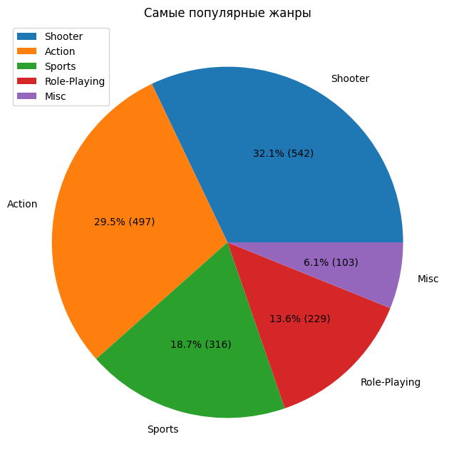

```python
# Частота встречаемости жанров в NA
(
    na.pivot_table(index='genre', values='na_sales', aggfunc='sum')
    .sort_values(by='na_sales',ascending=False).head(5)
    .plot(subplots=True,
          kind='pie',
          figsize=(10, 8),
          legend=True,
          autopct=lambda pct: f'{pct:.1f}% ({int(pct/100.*sum(na["platform"].value_counts()))})')
)

# Задание названия графика
plt.title('Самые популярные жанры')
plt.ylabel('')

# Показать график
plt.show()
```

Самым популярным жанром `NA` является `Shooter`, ближайшим конкурентом по показателям выступает `Action`. Не поплярный жанр игр в этом регионе является `Misc`.

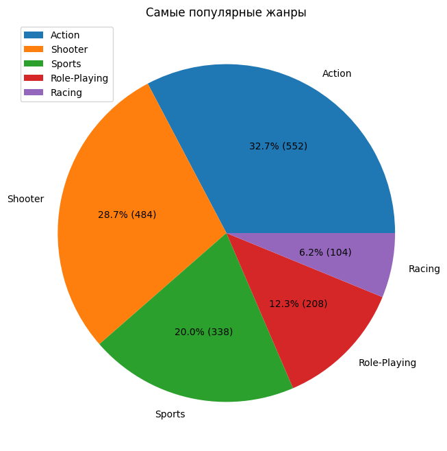

```python
# Частота встречаемости жанры в EU
(
    eu.pivot_table(index='genre', values='eu_sales', aggfunc='sum')
    .sort_values(by='eu_sales',ascending=False).head(5)
    .plot(subplots=True,
          kind='pie',
          figsize=(10, 8),
          legend=True,
          autopct=lambda pct: f'{pct:.1f}% ({int(pct/100.*sum(eu["platform"].value_counts()))})')
)

# Задание названия графика
plt.title('Самые популярные жанры')
plt.ylabel('')

# Показать график
plt.show()
```

Самым популярным жанром `EU` является `Action`, ближайшим конкурентом по показателям выступает `Shooter`. Не поплярный жанр игр в этом регионе является `Racing`.

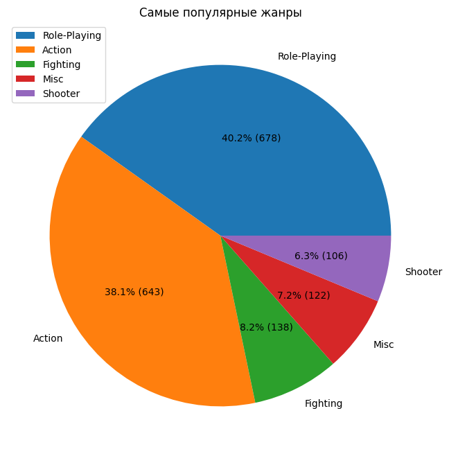

```python
# Частота встречаемости жанры в JP
(
    jp.pivot_table(index='genre', values='jp_sales', aggfunc='sum')
    .sort_values(by='jp_sales',ascending=False).head(5)
    .plot(subplots=True,
          kind='pie',
          figsize=(10, 8),
          legend=True,
          autopct=lambda pct: f'{pct:.1f}% ({int(pct/100.*sum(jp["platform"].value_counts()))})')
)

# Задание названия графика
plt.title('Самые популярные жанры')
plt.ylabel('')

# Показать график
plt.show()
```

Самым популярным жанром `JP` является `Role-Playing`, ближайшим конкурентом по показателям выступает `Action`. Не поплярный жанр игр в этом регионе является `Shooter`.

В `NA`:

- Лидирует жанр `Shooter`
- На втором месте `Action`
- Наименее популярен жанр `Misc`

В `EU`:

- На первом месте жанр `Action`
- Следом идет `Shooter`
- Наименее популярен жанр `Racing`

В `JP`:

- Доминирует жанр `Role-Playing`
- На втором месте `Action`
- Наименее популярен жанр `Shooter`

Интересно отметить, что жанр, который наименее популярен в одном регионе, может быть весьма востребован в другом. Например, шутеры, которые лидируют в `NA`, наименее популярны в `JP`.

**Влияет ли рейтинг ESRB на продажи в отдельном регионе?**

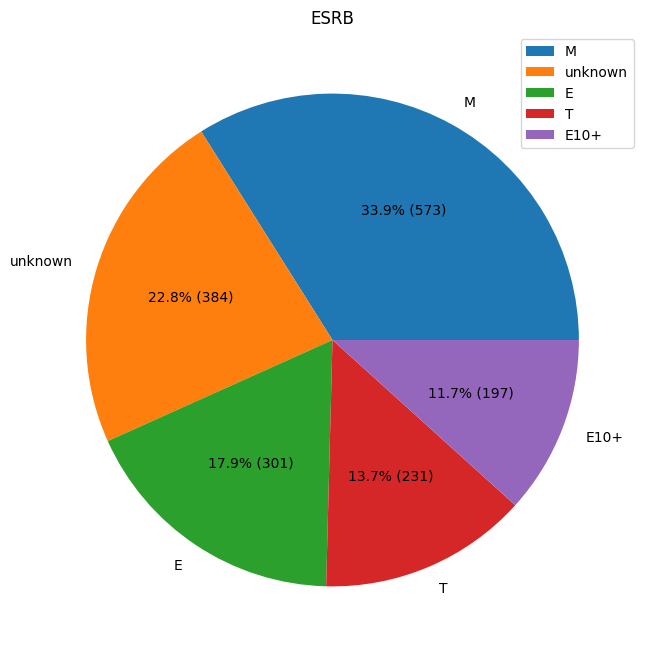

```python
# Влияние ESRB в NA
(
    na.pivot_table(index='rating', values='na_sales', aggfunc='sum')
    .sort_values(by='na_sales',ascending=False).head(5)
    .plot(subplots=True,
          kind='pie',
          figsize=(10, 8),
          legend=True,
          autopct=lambda pct: f'{pct:.1f}% ({int(pct/100.*sum(na["platform"].value_counts()))})')
)

# Задание названия графика
plt.title('ESRB')
plt.ylabel('')

# Показать график
plt.show()
```

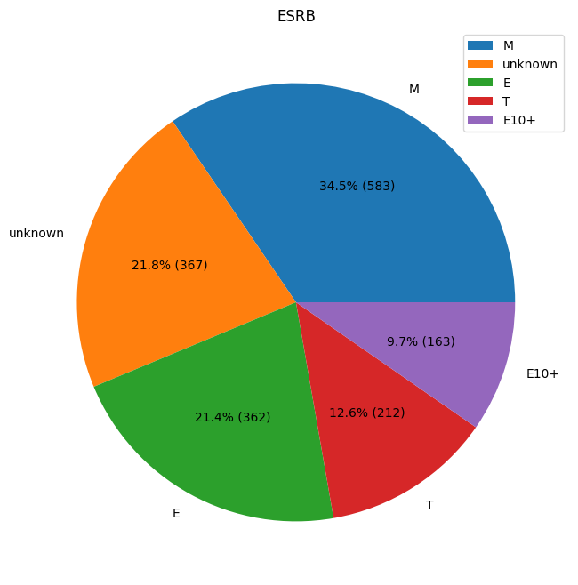

```python
# Влияние ESRB в EU
(
    eu.pivot_table(index='rating', values='eu_sales', aggfunc='sum')
    .sort_values(by='eu_sales',ascending=False).head(5)
    .plot(subplots=True,
          kind='pie',
          figsize=(10, 8),
          legend=True,
          autopct=lambda pct: f'{pct:.1f}% ({int(pct/100.*sum(eu["platform"].value_counts()))})')
)

# Задание названия графика
plt.title('ESRB')
plt.ylabel('')

# Показать график
plt.show()
```

[figure not shown]

```python
# Влияние ESRB в JP
(
    jp.pivot_table(index='rating', values='jp_sales', aggfunc='sum')
    .sort_values(by='jp_sales',ascending=False).head(5)
    .plot(subplots=True,
          kind='pie',
          figsize=(10, 8),
          legend=True,
          autopct=lambda pct: f'{pct:.1f}% ({int(pct/100.*sum(jp["platform"].value_counts()))})')
)

# Задание названия графика
plt.title('ESRB')
plt.ylabel('')

# Показать график
plt.show()
```

Из проведённого анализа видно, что рейтинг действительно влияет на продажи в разных регионах. В регионах `NA` и `EU` наблюдается схожая зависимость. Однако в регионе `JP` совершенно обратная картина по рейтингу.

## Проверка гипотез

**Средние пользовательские рейтинги платформ Xbox One и PC одинаковые**

Определим нулевую и альтернативную гипотезу:

- H0: *Средние пользовательские рейтинги платформ Xbox One и PC одинаковые (т.е. равны)*
- H1: *Средние пользовательские рейтинги платформ Xbox One и PC не равны*

H0 = H1  
H1 != H0

Какая гипотеза проверяется? - О равенстве средних двух генеральных совокупностей с двумя независимыми выборками

Для проверки равенства средних двух генеральных совокупностей используем метод `scipy.stats.ttest_ind`. Так же используем парметр `alternative='two-sided'`.

Не исключено, что дисперсии генеральных совокупностей различны `equal_var=False`, т.к. это разные платформы, разные игры, разный принцип взамиодействия с платформой. Благодаря ЦПТ можно считать, что совокупности нормально распределены

```python
top_current_platforms.query('platform == "XOne"').query('user_score != -2')['user_score']
```

```
165      7.9
179      5.4
242      6.4
270      6.2
373      4.1
        ...
16544    6.8
16597    6.0
16630    8.2
16643    6.6
16660    6.7
Name: user_score, Length: 165, dtype: float64
```

```python
top_current_platforms.query('platform == "XOne"').query('user_score != -2')['user_score'].unique()
```

```
array([7.9, 5.4, 6.4, 6.2, 4.1, 5.5, 7.5, 4.4, 7.2, 3.1, 6.1, 8.2, 6.9,
       6.3, 5.8, 6.6, 7.3, 8. , 9.2, 7.8, 8.4, 5.9, 5.1, 5.2, 7.7, 7.4,
       5.6, 7. , 6.7, 4.6, 5.7, 6.8, 8.1, 6. , 7.1, 3.2, 8.6, 8.5, 4.3,
       5.3, 4. , 8.3, 8.7, 2.1, 7.6, 4.9, 8.9, 1.6, 4.2, 8.8])
```

```python
top_current_platforms.query('platform == "PC"').query('user_score != -2')['user_score'].unique()
```

```
array([3.9, 5.4, 7.9, 5.7, 5.9, 9.3, 8. , 6.7, 6.2, 3. , 6.8, 8.3, 6. ,
       8.2, 4.7, 5.8, 4.5, 7.6, 5.5, 6.9, 7.5, 4.2, 7.3, 7.1, 4.4, 3.2,
       8.6, 4.3, 4.8, 6.4, 7.4, 8.4, 5.3, 8.9, 3.8, 2.5, 7. , 7.7, 2.9,
       3.6, 5.1, 4. , 3.5, 6.1, 6.3, 8.7, 7.8, 1.4, 3.7, 2.4, 8.5])
```

```python
# Определеим генеральные совокупности
a_xone_ttest = top_current_platforms.query('platform == "XOne"').query('user_score != -2')['user_score']
b_pc_ttest = top_current_platforms.query('platform == "PC"').query('user_score != -2')['user_score']

alpha = 0.05 # уровень статистической значимости

results = st.ttest_ind(a_xone_ttest, b_pc_ttest, equal_var=False)

print('p-значение:', results.pvalue)

if results.pvalue < alpha:
    print('Отвергаем нулевую гипотезу')
else:
    print('Не получилось отвергнуть нулевую гипотезу')
```

```
p-значение: 0.11601398086668835
Не получилось отвергнуть нулевую гипотезу
```

**Средние пользовательские рейтинги жанров Action (англ. «действие», экшен-игры) и Sports (англ. «спортивные соревнования») разные**

Определим нулевую и альтернативную гипотезу:

H0 = H1  
H1 != H0

Какая гипотеза проверяется? - О равенстве средних двух генеральных совокупностей с двумя независимыми выборками

Для проверки равенства средних двух генеральных совокупностей используем метод `scipy.stats.ttest_ind`. Так же используем парметр `alternative='two-sided'`.

Не исключено, что дисперсии генеральных совокупностей различны `equal_var=False`, т.к. это разные жанры, разные игры, разный принцип взамиодействия с игрой, разная ЦА. Благодаря ЦПТ можно считать, что совокупности нормально распределены

```python
top_current_platforms.query('genre == "Action"').query('user_score != -2')['user_score'].unique()
```

```
array([8.3, 7.9, 8.1, 6.3, 4.9, 7.6, 4.1, 8.2, 6.8, 8.6, 9. , 6.5, 5.1,
       7.3, 4.5, 5.8, 6.6, 8. , 6.1, 7.8, 7.5, 7.2, 6.2, 5. , 8.4, 8.7,
       7.1, 7. , 6.4, 7.4, 6.7, 5.4, 7.7, 4.6, 5.9, 3.4, 3. , 6.9, 3.7,
       5.6, 4.7, 4.2, 5.7, 3.6, 3.3, 4.3, 5.5, 8.5, 3.2, 8.8, 4.8, 2.5,
       5.3, 6. , 3.5, 3.8, 5.2, 2.4, 2. , 2.8, 3.1, 2.3])
```

```python
top_current_platforms.query('genre == "Sports"').query('user_score != -2')['user_score'].unique()
```

```
array([4.3, 5. , 5.7, 4.5, 6.7, 4.4, 5.9, 4.2, 3.2, 5.5, 7. , 6.1, 6.2,
       5.4, 4.9, 6.3, 3. , 2.9, 6.4, 2.7, 3.5, 7.4, 5.1, 7.8, 7.1, 3.1,
       7.2, 4.6, 3.3, 7.7, 4. , 6.9, 3.6, 6. , 8.2, 2.4, 2.8, 7.6, 5.3,
       6.8, 1.7, 8.7, 1.6, 5.8, 6.6, 8.3, 5.6, 1.5, 0.7, 3.8, 7.3, 4.1,
       2. , 2.1, 3.4, 0.2, 1.9, 6.5, 4.8, 8. , 3.7, 8.8, 1.4])
```

```python
# Определеим генеральные совокупности
a_аction_ttest = top_current_platforms.query('genre == "Action"').query('user_score != -2')['user_score']
b_sports_ttest = top_current_platforms.query('genre == "Sports"').query('user_score != -2')['user_score']

alpha = 0.05 # уровень статистической значимости

results = st.ttest_ind(a_аction_ttest, b_sports_ttest, equal_var=False)

print('p-значение:', results.pvalue)

if results.pvalue < alpha:
    print('Отвергаем нулевую гипотезу')
else:
    print('Не получилось отвергнуть нулевую гипотезу')
```

```
p-значение: 1.1825550382644557e-14
Отвергаем нулевую гипотезу
```

Вывод:

Поскольку p-значение практически равно 1.18×10^−14 и намного меньше уровня значимости (0.05), мы можем отвергнуть нулевую гипотезу. Это означает, что на основе имеющихся данных есть статистически значимых доказательств в пользу того, что средние пользовательские рейтинги для жанров Action и Sports различны.

**Промежуточный итог:**

- Для платформ Xbox One и PC:
  - Нулевая гипотеза (H₀): Средние пользовательские рейтинги на платформах Xbox One и PC **равны**.
    - **Нулевая гипотеза (H₀)** предполагает отсутствие различий между средними значениями двух выборок.
  - Альтернативная гипотеза (H₁): Средние пользовательские рейтинги на платформах Xbox One и PC **различаются**.
    - **Альтернативная гипотеза (H₁)** является противоположной нулевой гипотезе и предполагает, что существует статистически значимое различие между средними значениями двух выборок.
- Для жанров Action и Sports:
  - Нулевая гипотеза (H₀): Средние пользовательские рейтинги жанров Action и Sports **равны**.
    - **Нулевая гипотеза (H₀)** предполагает отсутствие различий между средними значениями двух выборок.
  - Альтернативная гипотеза (H₁): Средние пользовательские рейтинги жанров Action и Sports **различаются**.
    - **Альтернативная гипотеза (H₁)** является противоположной нулевой гипотезе и предполагает, что существует статистически значимое различие между средними значениями двух выборок.

Для проверки гипотез был применён t-test Стьюдента для двух независимых выборок. Этот критерий был выбран по следующим причинам:

- **Нормальное распределение данных**. Согласно Центральной предельной теореме, при большом размере выборок (более 30 наблюдений), распределение средних стремится к нормальному, даже если исходные данные не соответствуют нормальному распределению.
- **Независимость выборок**. Платформы и жанры рассматриваются как независимые группы, что соответствует предположению t-теста.
- **Дисперсии рассматриваемых генеральных совокупностей равны**. В случае неравенства дисперсий между выборками использовался параметр `equal_var=False`. Это позволяет корректировать расчет, если дисперсии в двух выборках существенно различаются.
- **Достаточный размер выборок**. Выборки, использованные для проверки гипотез, содержали достаточное количество наблюдений, что делает t-тест надёжным методом для сравнения средних значений.

В разделе «Проверка гипотез» были проведены два статистических теста для сравнения пользовательских рейтингов игр по разным платформам и жанрам. В частности, проверялись следующие гипотезы:

- Сравнение средних пользовательских рейтингов на платформах **Xbox One и PC**. Результаты t-теста показали, что нет статистически значимых различий в средних пользовательских оценках этих платформ.
- Сравнение средних пользовательских рейтингов для жанров **Action и Sports**. На основе t-теста, удалось обнаружить значимые различия в средних оценках этих жанров.

## Общий вывод

В ходе исследования была выполнена детальная работа с данными интернет-магазина компьютерных игр «Стримчик». Цель проекта состояла в выявлении закономерностей, которые могут помочь определить успешные продукты для дальнейшего продвижения и рекламы. Проект включал несколько ключевых этапов: